# Level Set

The `LevelSet` module implements a fire spread simulator using the **level set method**. A signed distance function `φ(x, y, t)` implicitly tracks the fire front:

| Region | Condition | Meaning |
| --- | --- | --- |
| Burned | `φ < 0` | Fire has passed |
| Front | `φ = 0` | Active fire perimeter |
| Unburned | `φ > 0` | Fuel ahead of fire |

The front evolves according to the Hamilton-Jacobi equation:

$$\frac{\partial \phi}{\partial t} + F |\nabla \phi| = 0$$

where $F(x, y, t) \geq 0$ is the local spread rate (e.g. from the Rothermel model).

## `LevelSetGrid`

```julia
grid = LevelSetGrid(100, 100, dx=30.0)
```

```
LevelSetGrid{Float64} 100×100 (t=0.0, burned=0/10000)
```

## Boundary Conditions

The `bc` keyword controls how the solver handles grid edges. Three built-in options are available:

| Type | Behavior | Physical Interpretation |
| --- | --- | --- |
| `ZeroNeumann()` | Zero-gradient at edges (default). Missing neighbors contribute zero to finite differences. | **Open boundaries** — the fire front can reach and exit the domain naturally. Most common choice for realistic simulations where the domain is a subset of a larger landscape. |
| `Dirichlet()` | Fixed-value edges. Edge cells are never updated by `advance!` or `reinitialize!`. | **Firebreak / barrier** — edge cells retain their initial values (unburned). Useful for modeling impassable boundaries like rivers, roads, or cleared fire lines. |
| `Periodic()` | Wrap-around. Edges reference values from the opposite side of the grid. | **Tiling / infinite landscape** — fire exiting one edge enters from the opposite side. Useful for studying fire behavior in a homogeneous landscape without edge effects. |

```julia
grid_d = LevelSetGrid(50, 50, dx=30.0, bc=Dirichlet())
grid_p = LevelSetGrid(50, 50, dx=30.0, bc=Periodic())
println("Dirichlet: ", grid_d)
println("Periodic:  ", grid_p)
```

```
Dirichlet: LevelSetGrid{Float64}(50×50)
Periodic:  LevelSetGrid{Float64}(50×50)
```

### Custom Boundary Conditions

Define a custom BC by subtyping `AbstractBoundaryCondition` and implementing the four one-sided finite-difference helpers. Optionally implement `_skip_update` to exclude certain cells from updates.

```julia
using Wildfires.LevelSet

struct MyBC <: AbstractBoundaryCondition end

# One-sided finite differences at boundaries:
#   _Dxm(φ, i, j, dx, bc)        → backward x-difference
#   _Dxp(φ, i, j, nx, dx, bc)    → forward x-difference
#   _Dym(φ, i, j, dy, bc)        → backward y-difference
#   _Dyp(φ, i, j, ny, dy, bc)    → forward y-difference

# Optional: skip updating certain cells (default: false)
#   _skip_update(i, j, ny, nx, bc) → Bool
```

See the built-in implementations in `src/LevelSet.jl` for reference.

### Coordinates

```julia
xs = xcoords(grid)
println("x: $(first(xs)) to $(last(xs)) m  ($(length(xs)) cells)")

ys = ycoords(grid)
println("y: $(first(ys)) to $(last(ys)) m  ($(length(ys)) cells)")
```

```
x: 15.0 to 2985.0 m  (100 cells)
y: 15.0 to 2985.0 m  (100 cells)
```

## Ignition

```julia
ignite!(grid, 1500.0, 1500.0, 100.0)
grid
```

```
LevelSetGrid{Float64} 100×100 (t=0.0, burned=32/10000, ignited=32)
```

## Queries

```julia
burn_area(grid)  # m²
```

```
28800.0
```

```julia
sum(burned(grid))  # number of burned cells
```

```
32
```

## Advancing the Front

The spread rate field `F` has the same dimensions as the grid. Each cell specifies the local spread rate in m/min.

```julia
F = fill(10.0, size(grid))  # uniform 10 m/min everywhere

for _ in 1:20
    advance!(grid, F, 0.5)
end

grid
```

```
LevelSetGrid{Float64} 100×100 (t=10.0, burned=264/10000, ignited=264)
```

## Solvers

The `advance!` function accepts an optional solver argument that controls the numerical scheme for evolving the level set equation. Three solvers are available:

| Solver | Order | Time Stepping | Stencil | Use Case |
| --- | --- | --- | --- | --- |
| `Godunov()` | 1st | Forward Euler | 1-cell | Default — robust, simple, good for most cases |
| `Superbee()` | 2nd | RK2 (Heun) | 2-cell | Sharper fronts, less numerical diffusion |
| `WENO5()` | 5th | SSP-RK3 | 3-cell | Highest accuracy, sharpest front resolution |

```julia
# Explicit solver selection (Godunov is the default)
advance!(grid, F, 0.5, Godunov())

# Second-order Superbee
grid2 = LevelSetGrid(100, 100, dx=30.0)
ignite!(grid2, 1500.0, 1500.0, 100.0)
F2 = fill(10.0, size(grid2))
advance!(grid2, F2, 0.5, Superbee())
grid2
```

```
LevelSetGrid{Float64} 100×100 (t=0.5, burned=52/10000, ignited=52)
```

When no solver is specified, `advance!(grid, F, dt)` defaults to `Godunov()` for backward compatibility.

### `Godunov()` — First-Order Upwind

The default solver computes $|\nabla\phi|$ using **Godunov’s upwind scheme**, a monotone numerical flux for Hamilton-Jacobi equations. The idea is to use one-sided (upwind) finite differences that respect the direction information is traveling — toward the fire front.

At each cell, four one-sided differences are computed:

$$D_x^- = \frac{\phi_{i,j} - \phi_{i,j-1}}{\Delta x}, \quad D_x^+ = \frac{\phi_{i,j+1} - \phi_{i,j}}{\Delta x}$$

$$D_y^- = \frac{\phi_{i,j} - \phi_{i-1,j}}{\Delta y}, \quad D_y^+ = \frac{\phi_{i+1,j} - \phi_{i,j}}{\Delta y}$$

Since the spread rate $F \geq 0$, the front moves in the direction of $\nabla\phi$ (outward from burned regions). Godunov’s scheme selects the appropriate one-sided difference in each coordinate:

$$\hat{D}_x = \max\!\bigl(\max(D_x^-,\, 0),\; -\min(D_x^+,\, 0)\bigr)$$

$$\hat{D}_y = \max\!\bigl(\max(D_y^-,\, 0),\; -\min(D_y^+,\, 0)\bigr)$$

Then $|\nabla\phi| \approx \sqrt{\hat{D}_x^2 + \hat{D}_y^2}$ and the update is:

$$\phi^{n+1}_{i,j} = \phi^n_{i,j} - \Delta t \; F_{i,j} \; \sqrt{\hat{D}_x^2 + \hat{D}_y^2}$$

This selection rule ensures that only **upstream** information influences the update, preventing oscillations that would occur with central differences. At domain boundaries, the one-sided differences that would require out-of-bounds data are set to zero (implicit zero-Neumann / reflective boundary condition).

### `Superbee()` — Second-Order TVD

The `Superbee` solver converts the Hamilton-Jacobi equation into advection form and applies a **Superbee flux limiter** with **RK2 (Heun’s method)** time stepping, following the approach used in [ELMFIRE](https://github.com/lautenberger/elmfire). This produces sharper fire fronts with less numerical diffusion than the first-order Godunov scheme.

**How it works:**

1. Compute the front normal $\hat{n} = \nabla\phi / |\nabla\phi|$ via central differences
2. Set advection velocities $u_x = F \cdot n_x$, $u_y = F \cdot n_y$
3. Apply the Superbee flux limiter to compute limited gradients $\partial\phi/\partial x$, $\partial\phi/\partial y$
4. Advance with RK2 (Heun’s method):
   - **Stage 1**: Forward Euler $\phi^* = \phi^n - \Delta t \, (u_x \, \partial\phi/\partial x + u_y \, \partial\phi/\partial y)$
   - **Stage 2**: Recompute from $\phi^*$, then average: $\phi^{n+1} = \tfrac{1}{2}(\phi^n + \phi^{**})$

The Superbee limiter is **total variation diminishing (TVD)**, preventing spurious oscillations while maintaining second-order accuracy at smooth regions. It uses a 2-cell stencil (accessing `φ[i±2, j±2]`), wider than Godunov’s 1-cell stencil.

**Parameters:**

```julia
Superbee(phi_clamp=100.0, grad_clamp=1000.0)
```

| Parameter | Default | Description |
| --- | --- | --- |
| `phi_clamp` | `100.0` | Clamp `φ` values to `[-phi_clamp, phi_clamp]` after each RK stage |
| `grad_clamp` | `1000.0` | Clamp flux-limited gradients to prevent runaway values |

These guards prevent numerical blowup when the level set field develops steep gradients or large values far from the front.

### `WENO5()` — Fifth-Order WENO

The `WENO5` solver uses the **Jiang-Shu WENO5** (Weighted Essentially Non-Oscillatory) reconstruction for spatial derivatives with **SSP-RK3** (Strong Stability Preserving Runge-Kutta) time stepping. This provides 5th-order accuracy in smooth regions while maintaining sharp resolution near discontinuities.

**How it works:**

1. Compute left-biased ($D^-$) and right-biased ($D^+$) WENO5 derivatives in each direction using a 6-point stencil
2. Each WENO5 derivative blends three candidate 3rd-order stencils weighted by smoothness indicators — smooth regions get near-optimal weights, while oscillatory regions suppress offending stencils
3. Apply the Godunov numerical Hamiltonian (same as first-order) to combine derivatives
4. Advance with SSP-RK3 (Shu-Osher form):
   - **Stage 1**: $\phi_1 = \phi^n + \Delta t \cdot L(\phi^n)$
   - **Stage 2**: $\phi_2 = \tfrac{3}{4}\phi^n + \tfrac{1}{4}(\phi_1 + \Delta t \cdot L(\phi_1))$
   - **Stage 3**: $\phi^{n+1} = \tfrac{1}{3}\phi^n + \tfrac{2}{3}(\phi_2 + \Delta t \cdot L(\phi_2))$

The 3-cell stencil (accessing `φ[i±3, j±3]`) is the widest of the three solvers.

**Parameters:**

```julia
WENO5(phi_clamp=100.0)
```

| Parameter | Default | Description |
| --- | --- | --- |
| `phi_clamp` | `100.0` | Clamp `φ` values to `[-phi_clamp, phi_clamp]` after each RK stage |

### Comparing Solvers

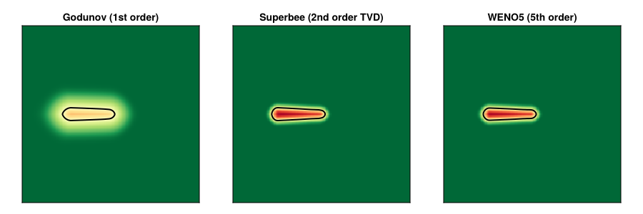

```julia
using Wildfires.SpreadModels
using Wildfires.Rothermel: SHORT_GRASS, FuelClasses

M = FuelClasses(d1=0.06, d10=0.07, d100=0.08, herb=0.0, wood=0.0)
model = RothermelModel(SHORT_GRASS, UniformWind(speed=8.0), UniformMoisture(M), FlatTerrain())

fig = Figure(size=(900, 300))
for (col, (label, solver)) in enumerate([
    ("Godunov (1st order)", Godunov()),
    ("Superbee (2nd order TVD)", Superbee()),
    ("WENO5 (5th order)", WENO5()),
])
    g = LevelSetGrid(200, 200, dx=30.0)
    ignite!(g, 3000.0, 3000.0, 50.0)
    simulate!(g, model, steps=100, dt=0.5, solver=solver)
    ax = Axis(fig[1, col], title=label, aspect=DataAspect())
    fireplot!(ax, g)
    hidedecorations!(ax)
end
fig
```

**TipWhen to use which solver**

- **`Godunov()`** is the safe default — it’s simple, robust, and sufficient for most simulations.
- **`Superbee()`** is worth trying when you need sharper fire front resolution, especially for high-resolution grids or when comparing against observed fire perimeters. It requires roughly 2x the computation per time step (two RK stages + wider stencil).
- **`WENO5()`** provides the highest accuracy and sharpest fronts, but at roughly 3x the cost of Godunov (three RK stages + wider stencil). Best for high-resolution research simulations.

### CFL Condition

The time step `dt` must satisfy the **Courant-Friedrichs-Lewy (CFL) condition** for numerical stability:

$$\text{dt} \leq \text{cfl} \cdot \frac{\min(\text{dx}, \text{dy})}{\max(F)}$$

where `cfl` is a safety coefficient (default `0.5`). If `dt` is too large, the upwind scheme becomes unstable and `φ` values will diverge.

The `cfl_dt` function computes a stable time step:

```julia
F = fill(10.0, size(grid))
cfl_dt(grid, F)           # cfl=0.5 by default
```

```
1.5
```

```julia
cfl_dt(grid, F; cfl=1.0)  # less conservative
```

```
3.0
```

The `simulate!` function uses automatic CFL-limited time stepping by default. Pass an explicit `dt` to override:

```julia
simulate!(grid, model, steps=100)                          # auto CFL (recommended)
simulate!(grid, model, steps=100, dt=0.5)                  # fixed dt
simulate!(grid, model, steps=100, solver=Superbee())       # 2nd-order solver
simulate!(grid, model, steps=100, solver=WENO5())          # 5th-order solver
```

## Reinitialization

Over many time steps, `φ` can drift away from a true signed distance function (gradients become too flat or too steep). Periodic reinitialization restores `|∇φ| ≈ 1`, which keeps the upwind scheme accurate.

```julia
reinitialize!(grid)
grid
```

```
LevelSetGrid{Float64} 100×100 (t=10.5, burned=280/10000, ignited=280)
```

Two reinitialization methods are available:

| Method | Accuracy | Cost | Use Case |
| --- | --- | --- | --- |
| `IterativeReinit(iterations=5)` | Approximate | Low | Default — fast, good enough for most simulations |
| `NewtonReinit(upsample=8)` | Machine-precision | Higher | Research — exact signed distance restoration |

### `NewtonReinit` — Newton Closest-Point

The Newton method produces machine-precision signed distance fields by:

1. Building a cubic interpolant of `φ` using `Interpolations.jl`
2. Locating zero-contour sample points via Newton projection
3. Building a KD-tree for efficient nearest-neighbor queries
4. Computing exact signed distance from each grid point to the nearest interface point

```julia
reinitialize!(grid, NewtonReinit())
reinitialize!(grid, NewtonReinit(upsample=16, maxiters=30))
```

In `simulate!`, pass the `reinit` keyword:

```julia
simulate!(grid, model, steps=100, reinit=NewtonReinit())
```

## Curvature Regularization

The `curvature` keyword in `simulate!` adds curvature-dependent speed regularization:

$$F_{\text{eff}} = \max(F - b \cdot \kappa, 0)$$

where $b$ is the curvature coefficient and $\kappa$ is the mean curvature of the level set. This smooths the fire front by reducing speed at convex bulges and increasing it at concave indentations.

```julia
simulate!(grid, model, steps=100, curvature=5.0)
```

The mean curvature is computed via central differences:

$$\kappa = \frac{\phi_{xx}\phi_y^2 - 2\phi_x\phi_y\phi_{xy} + \phi_{yy}\phi_x^2}{(\phi_x^2 + \phi_y^2)^{3/2}}$$

When `curvature > 0`, the CFL time step also enforces the parabolic constraint $\Delta t \leq \Delta x^2 / (2b)$. For typical fire simulation parameters, this is never the bottleneck.

## Plotting

### Standard Makie Plots

The `LevelSetGrid` integrates with Makie’s `heatmap`, `contour`, `contourf`, and `surface` via `convert_arguments`:

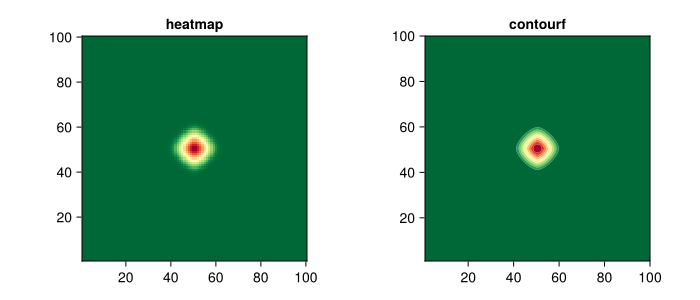

```julia
fig = Figure(size=(700, 300))
ax1 = Axis(fig[1, 1], title="heatmap", aspect=DataAspect())
heatmap!(ax1, grid, colormap=:RdYlGn)

ax2 = Axis(fig[1, 2], title="contourf", aspect=DataAspect())
contourf!(ax2, grid, colormap=:RdYlGn)
fig
```

### `fireplot`

The `fireplot` recipe combines a heatmap of `φ` with a contour line at the fire front:

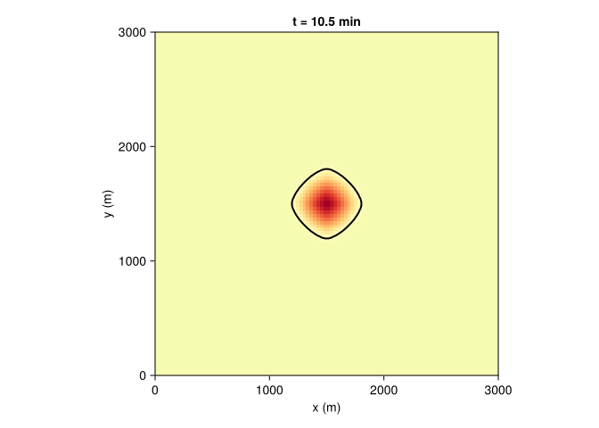

```julia
fig = Figure()
ax = Axis(fig[1, 1], title="t = $(grid.t) min", aspect=DataAspect(),
    xlabel="x (m)", ylabel="y (m)")
fireplot!(ax, grid)
fig
```

## Full Example

Simulate fire spread with a spatially varying spread rate and visualize snapshots:

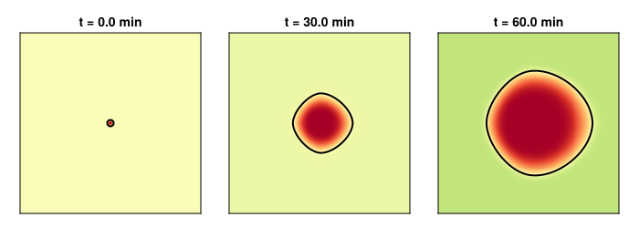

```julia
# Fresh grid with ignition
g = LevelSetGrid(200, 200, dx=15.0)
ignite!(g, 1500.0, 1500.0, 50.0)

# Spread rate: faster on the right side (x increases with column j)
F = [2.0 + 18.0 * (j / 200)
    for i in 1:200, j in 1:200]

fig = Figure(size=(700, 250))
times = [0, 30, 60]
for (col, target_t) in enumerate(times)
    while g.t < target_t
        advance!(g, F, 0.25)
    end
    col > 1 && reinitialize!(g)
    t = round(g.t, digits=1)
    ax = Axis(fig[1, col],
        title="t = $t min",
        aspect=DataAspect())
    fireplot!(ax, g)
    hidedecorations!(ax)
end
fig
```

## References

- Osher, S. & Sethian, J.A. (1988). *Fronts propagating with curvature-dependent speed.* J. Computational Physics, 79(1), 12–49.
- Mallet, V., Keyes, D.E., & Fendell, F.E. (2009). *Modeling wildland fire propagation with level set methods.* Computers & Mathematics with Applications.
- Lautenberger, C. (2013). *Wildland fire modeling with an Eulerian level set method and automated calibration.* Fire Safety Journal, 62, 289–298. (ELMFIRE — Superbee flux limiter approach)
- Jiang, G.-S. & Peng, D. (2000). *Weighted ENO schemes for Hamilton-Jacobi equations.* SIAM J. Scientific Computing, 21(6), 2126–2143. (WENO5 for level set methods)